# The Gifts of R: Packages

November 09, 2020

### What are Packages?

Packages are a way to share code. A package contains the code, any documentation, any required data and tests for performance. There are well over 14,000 packages available for download.

This is awesome!

And this is terrifying!

You can do it all in base R….but why?

A package can contain many different functions. Functions are what you call to execute code in r. For example, `summary()` is a function, but it is loaded into base R. But `select()` (which I will talk about later) is a function in the `dplyr` package.

Sometimes you find a function (via Google) but to use it you need to know what package to install. [Here is an example.](https://www.rdocumentation.org/packages/dplyr/versions/0.7.8/topics/select)

### Where do you get packages?

Most people get their packages from [CRAN](https://cran.r-project.org/web/packages/policies.html) (Comprehensive R Archive Network) which is the main repository for package files. This is a controlled repository and it for a package to be published here it has to pass several tests.

Packages are shared on [Github](https://github.com/) and most of these are developmental (untested). But can be very useful, like [`ggbarf()`](https://github.com/karawoo/ggbarf).

### How to install packages

You can do this through the GUI interface in R-studio, but that is risky.

It is better to install them using the command line: `install.packages()`.

### How to use a package

To use a package you have to use a `library()` statement.

For example I can’t use any of the functions in the `dplyr` package until I use the following statement:

```r
library(dplyr)
```

To list all fo the functions that are contained in a package use `lsf.str("package: PACKAGENAME")`

### How to manage packages

There is a package you can use to manage all of your packages. Its called [`pacman`](https://www.rdocumentation.org/packages/pacman/versions/0.5.1).

```r
pacman::p_load(dplyr, doParallel, nnet, caret, randomForest, ggplot2, ROCR, ipred, pROC, DataExplorer, stringi, lubridate, reshape)
```

### A reccomended package

#### [`DataExplorer()`](https://boxuancui.github.io/DataExplorer/)

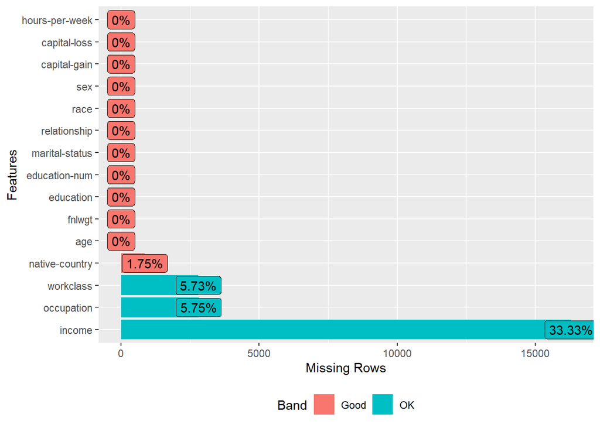

```r
library(arules)

data("AdultUCI")
plot_missing(AdultUCI)
```

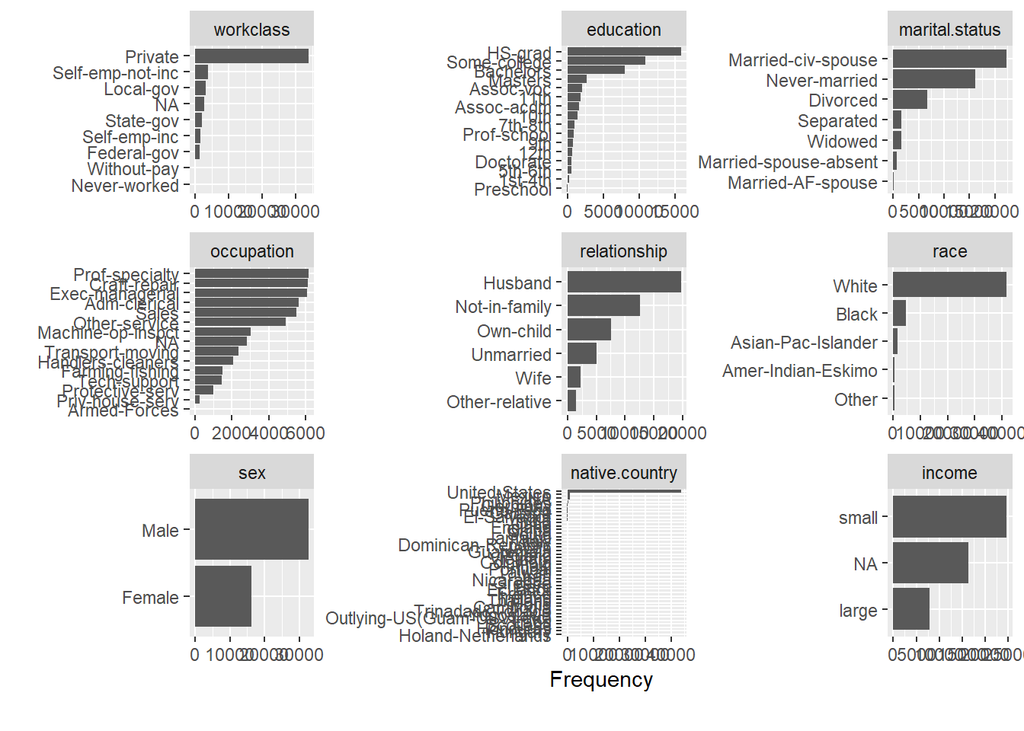

```r
plot_bar(AdultUCI)
```

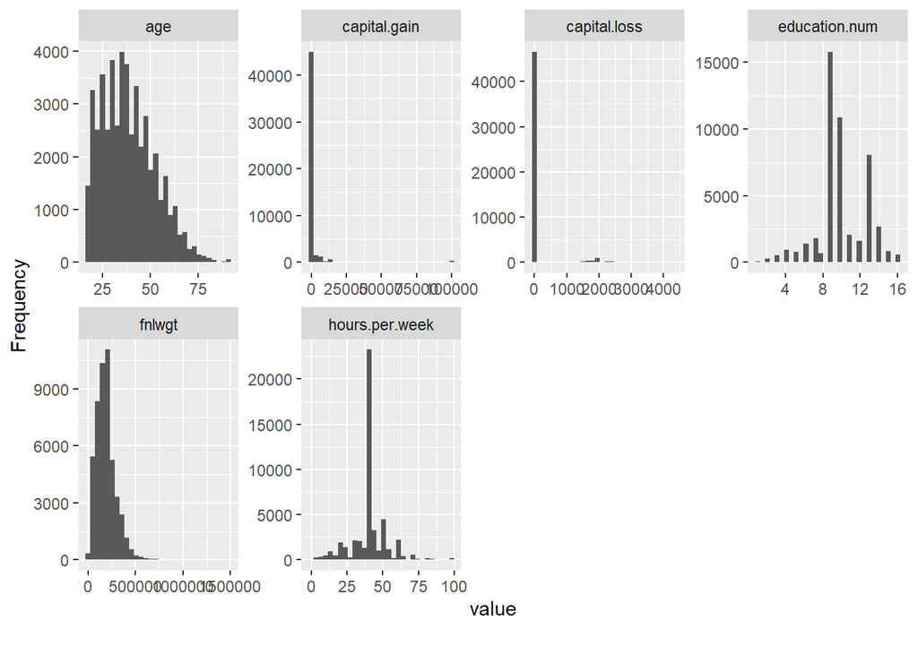

```r
plot_histogram(AdultUCI)
```

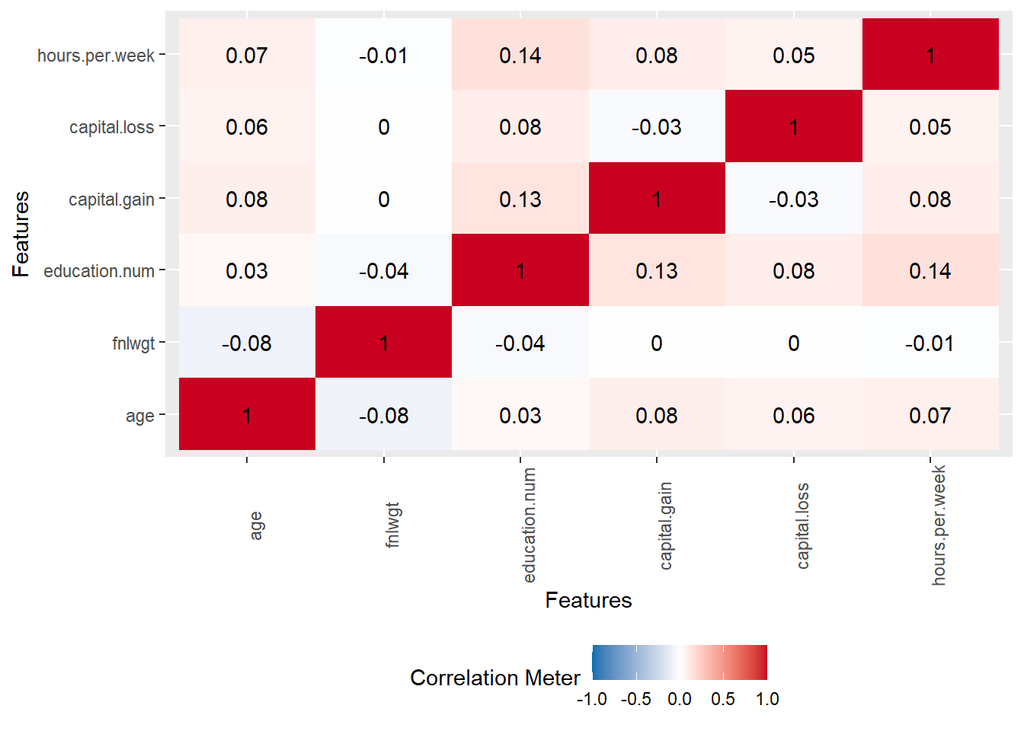

```r
plot_correlation(AdultUCI, type="continuous")
```

### Some of my favorite data manipulation functions

#### `select()`

From `dplyr()`

```r
df<-mtcars
subset<-select(df, mpg, disp, hp)
df<-select(df, -carb, -gear)
```

#### `melt()`

From `reshape2()`.

```r
 x = data.frame(
  id   = c(1, 1, 2, 2),
  color = c(1,1,1,1),
  blue = c(1, 0, 1, 0),
  red  = c(0, 1, 0, 1)
)
x
```

```
##   id color blue red
## 1  1     1    1   0
## 2  1     1    0   1
## 3  2     1    1   0
## 4  2     1    0   1
```

```r
x<-melt(x, id.vars=c("id", "color"))
x
```

```
##   id color variable value
## 1  1     1     blue     1
## 2  1     1     blue     0
## 3  2     1     blue     1
## 4  2     1     blue     0
## 5  1     1      red     0
## 6  1     1      red     1
## 7  2     1      red     0
## 8  2     1      red     1
```

#### `recode_factor()`

From `dplyr()`.

```r
x$variable<-recode_factor(x$variable, "blue"="B", "red"="R")
x
```

```
##   id color variable value
## 1  1     1        B     1
## 2  1     1        B     0
## 3  2     1        B     1
## 4  2     1        B     0
## 5  1     1        R     0
## 6  1     1        R     1
## 7  2     1        R     0
## 8  2     1        R     1
```

#### `colsplit()`

From `reshape2`

```r
x<-c("jan-20", "feb-13", "mar-14")
colsplit(x, "-", c("month", "day"))
```

```
##   month day
## 1   jan  20
## 2   feb  13
## 3   mar  14
```

### Others packages that I use

[`ggplot2`](https://ggplot2.tidyverse.org/reference/)

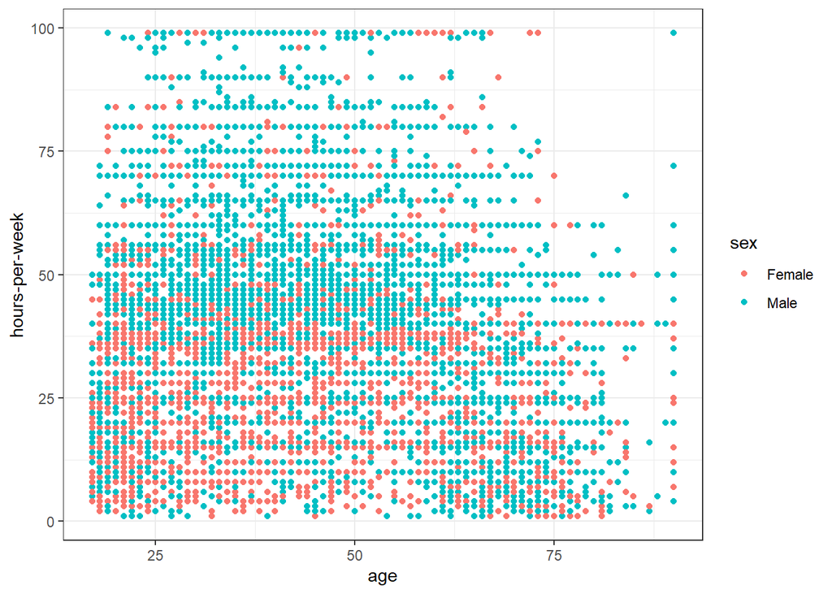

```r
library(ggplot2)

ggplot(AdultUCI, aes(x=age, y=`hours-per-week`, color=sex))+geom_point()+theme_bw()
```

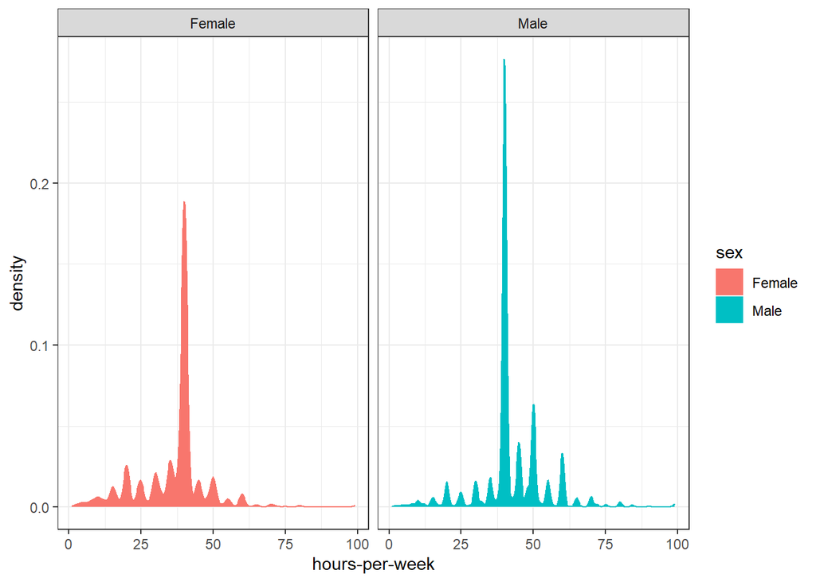

```r
ggplot(AdultUCI, aes(x=`hours-per-week`, y= , color=sex, fill=sex))+geom_density()+facet_grid(~sex)+theme_bw()
```

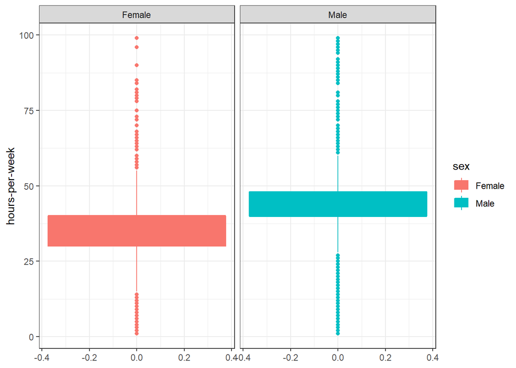

```r
ggplot(AdultUCI, aes(x=, y=`hours-per-week`, color=sex, fill=sex))+geom_boxplot()+facet_grid(~sex)+theme_bw()
```

[`lubridate`](https://lubridate.tidyverse.org/)

```r
ymd("20110604")
```

```
## [1] "2011-06-04"
```

```r
mdy("06-04-2011")
```

```
## [1] "2011-06-04"
```

```r
dmy("04/06/2011")
```

```
## [1] "2011-06-04"
```